# Unsupervised Learning Lab II (L04)

Data Science III (STAT 301-3)

April 28th, 2019

# Overview

The goal of this lab is to continue practicing the application of unsupervised learning techniques.

# Datasets

We will be utilizing the `USArrests` data (*USArrests.csv*) which is contained in the **data** subdirectory. Students are able to access the appropriate codebook using `USArrests`. We we also be using the `college_reshaped.csv` dataset which contains both categorical and numerical data (found in **data** subdirectory). The dataset was formed using the `College` dataset from the `ISLR` package.

# Exercises

Please complete the following exercises. The document should be neatly formatted.

#### Load Packages

```r
# Loading package(s)
library(ISLR)
library(kernlab)
library(gridExtra)
library(ggdendro)
library(magrittr)
library(janitor)
library(skimr)
library(usmap)
library(ggplot2)
library(cdlTools)
library(cluster)
library(tidyverse)
```

#### Exercise 1 (Ex. 9 Section 10.7 pg 416)

Consider the `USArrests` data. Perform hierarchical clustering on the states.

```r
# Load data
usar = read_csv("data/USArrests.csv") %>%
  clean_names()
```

1. Using hierarchical clustering with complete linkage and Euclidean distance, cluster the states.

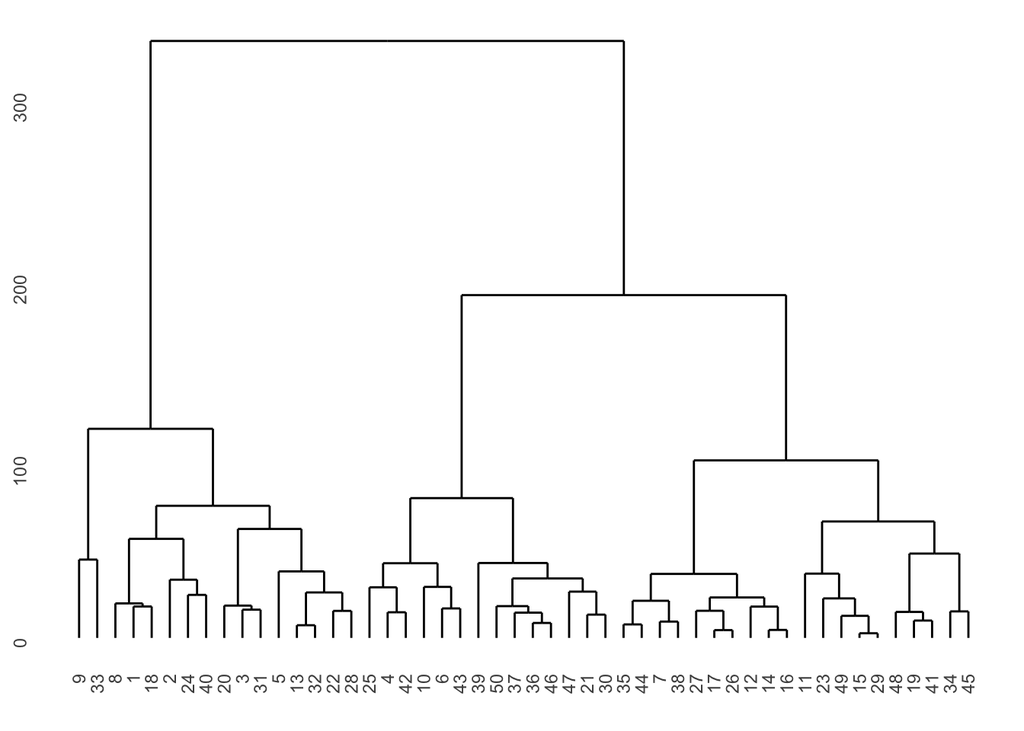

```r
# helper function
# get dendogram
run_hclust <- function(x, meth){
  return(hclust(dist(x), method = meth))
}
# obtain dendogram for data
usar_hclust <- tibble(usar = list(usar)) %>%
  mutate(hcl = map2(usar, "complete", run_hclust), # get dendos
         dendo = map(hcl, ggdendrogram)) # plot dendos
# look at the dendo
usar_hclust %>% pluck("dendo", 1)
```

2. Cut the dendrogram at a height that results in three distinct clusters. Which states belong to which clusters? *Challenge: Maybe plotting a map and filling by cluster membership might be a good idea.*

```r
# helper function to convert to fipss
# get the clusterings
cut_hclust <- function(hclust_obj, ncuts){
  return(cutree(hclust_obj, ncuts))
}
# Get cluster labels for the data
get_cluster <- function(x, clust_obj){
  if(class(clust_obj) == "kmeans"){
    clust = clust_obj$cluster
  } else {
    clust = clust_obj
  }
  out = x %>%
    mutate(cluster = clust)
  return(out)
}

# get the cluster data
usar_hclust <- usar_hclust %>%
  mutate(clusters = map2(hcl, 3, cut_hclust), # Cut dendo
         clust_dat = map2(usar, clusters, get_cluster)) # Get cluster info
```

#### Plot a map and fill by cluster membership

```r
# helper function to get fips
fips <- function( x , to ='FIPS') {

  # handle the case of multiple items
  if(length(x) > 1) {
    if(!is.null(ncol(x))) return( apply(x, 1:2, fips, to=to) )
    return( sapply( x, fips, to=to ) )
  }
    # for matching convert to upper case
    x <- sub(" ","",toupper(as.character(x)))

    # check if x contains numbers
    if( grepl("[0-9]",x[1]) ) {
      # if the two letters are actually numbers we convert to numeric
      # and return the abbreviation
      if(as.numeric(x) %in% cdlTools::census2010FIPS$State.ANSI) {
        return(as.numeric(x))
      } else return(NA)
    }

    # if it is a full state name convert to
    if( x %in% sub(" ","",toupper(as.character(cdlTools::stateNames$STATENAME)))) {
      x <- cdlTools::stateNames[x == sub(" ","",toupper(as.character(cdlTools::stateNames$STATENAME))),'STATE'][1]
      x <- as.character(x)
    }

    # if the two letters are in the state factor we return the fips
    if( x %in% as.character(cdlTools::census2010FIPS$State) ) {
      return( cdlTools::census2010FIPS[x == as.character(cdlTools::census2010FIPS$State), 'State.ANSI'][1] )
    }

    return(NA)

}

#  helper function to plot US map
plotmap <- function(dat){
  plot_usmap(data = dat, values = "cluster", labels = TRUE, label_color = "white") +
  scale_fill_discrete(name = "cluster") +
  theme(legend.position = "right")
}
```

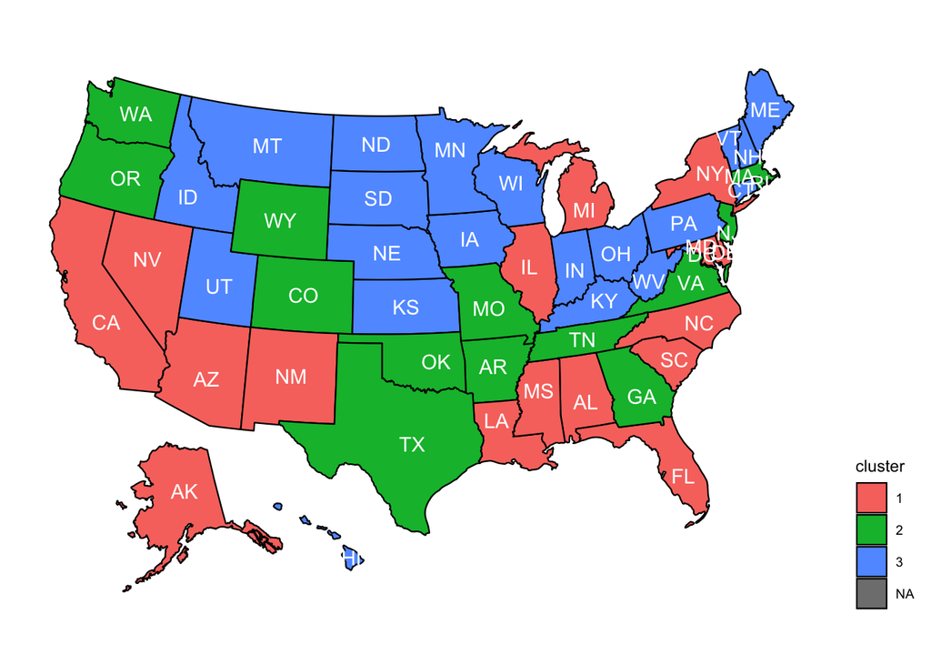

```r
# show the clustering result
clust_result <- usar_hclust$clust_dat[[1]]
clust_result <- clust_result %>%
  select("cluster", "state_name") %>%
  rename(fips = state_name)
clust_result$fips <- fips(clust_result$fips)
clust_result$fips[8] <- c(10)
clust_result$cluster <- as.factor(clust_result$cluster)
plotmap(clust_result)
```

3. Hierarchically cluster the states using complete linkage and Euclidean distance, after scaling the variables to have standard deviation one.

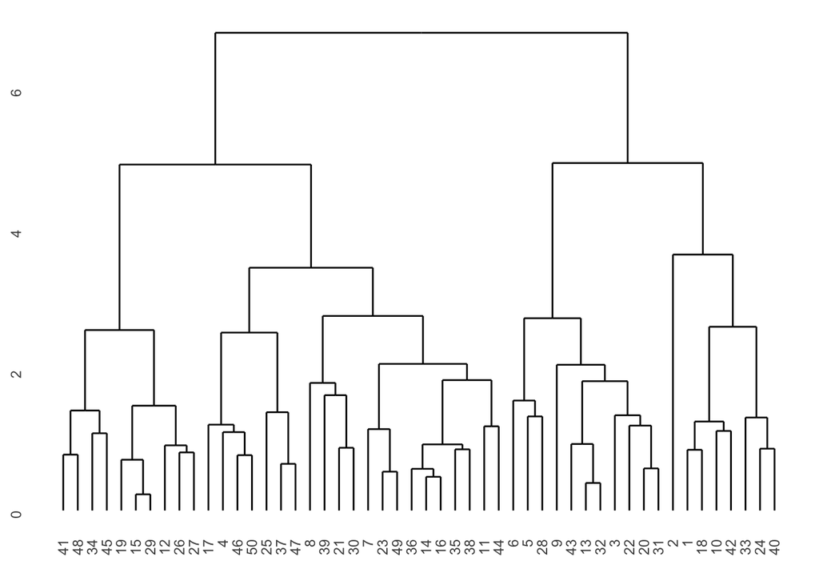

```r
# scale variables
scaledusar <- cbind(usar[,1], scale(usar[,2:5]))
# obtain dendogram for scaled data
scaledusar_hclust <- tibble(scaledusar = list(scaledusar)) %>%
  mutate(scaledhcl = map2(scaledusar, "complete", run_hclust), # get dendos
         scaleddendo = map(scaledhcl, ggdendrogram)) # plot dendos
# look at the dendo
scaledusar_hclust %>% pluck("scaleddendo", 1)
```

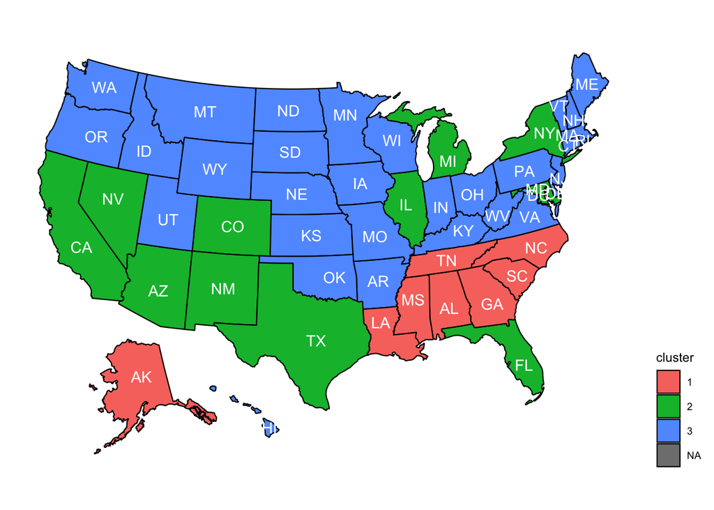

```r
# get the cluster data
scaledusar_hclust <- scaledusar_hclust %>%
  mutate(clusters = map2(scaledhcl, 3, cut_hclust), # Cut dendo
         clust_dat = map2(scaledusar, clusters, get_cluster)) # Get cluster info

# show the result & plot the map
scaledclust_result <- scaledusar_hclust$clust_dat[[1]]
scaledclust_result <- scaledclust_result %>%
  select("cluster", "state_name") %>%
  rename(fips = state_name)
scaledclust_result$fips <- fips(scaledclust_result$fips)
scaledclust_result$fips[8] <- c(10)
scaledclust_result$cluster <- as.factor(scaledclust_result$cluster)
plotmap(scaledclust_result)
```

4. What effect does scaling the variables have on the hierarchical clustering obtained? In your opinion, should the variables be scaled before the inter-observation dissimilarities are computed? Provide a justification for your answer.  
   After scaling, all the variables are in the same scale, so no single variable has very large effect. I think the variables should be scaled before the inter-observation dissimilarities are computed because comparison should happen when all variables are under the same scale.

#### Exercise 2

Consider the the `college_reshaped.csv` dataset. Scale the numerical features so that they have a standard deviation of one.

```r
# Load data
college = read_csv("data/college_reshaped.csv") %>%
  clean_names() %>%
  mutate_at(vars(name, private, is_elite), factor)
# scale variables
scaledcollege <- cbind(college[,c(1,6,7)], scale(college[,2:5]))
# onehot encode
onescaledcollege <- scaledcollege %>%
  onehot::onehot() %>%
  predict(scaledcollege)

onedata <- tibble(xmat = onescaledcollege %>% list()) %>%
  mutate(college = college %>% list())
```

1. Run $K$-means on the data. Try different numbers of clusters $K$. Does a specific value of $K$ tend to produce better or more distinct clusters?

```r
# helper function
# Extract within-cluster SS from K-means object
get_within_ss <- function(kmean_obj){
  return(kmean_obj$tot.withinss)
}
# Get cluster labels for the data
getkmeanscluster <- function(x, clust_obj){
    clust = clust_obj$cluster
  out = x %>%
    mutate(cluster = clust)
  return(out)
}

college_kmeans =  onedata%>%
  crossing(nclust = 2:6) %>%
  mutate(kmean = map2(xmat, nclust, kmeans, nstart=20), # Fit K-means
         clusters = map2(college, kmean, getkmeanscluster)) # Get DFs with cluster affiliation
# show k-means results
college_kmeans %>%
  pluck("clusters", 1) %>%
  select("name", "cluster")
```

```
## # A tibble: 777 x 2
##    name                         cluster
##    <fct>                          <int>
##  1 Abilene Christian University       1
##  2 Adelphi University                 2
##  3 Adrian College                     2
##  4 Agnes Scott College                2
##  5 Alaska Pacific University          1
##  6 Albertson College                  2
##  7 Albertus Magnus College            2
##  8 Albion College                     2
##  9 Albright College                   2
## 10 Alderson-Broaddus College          1
## # … with 767 more rows
```

```r
college_kmeans %>%
  pluck("clusters", 2) %>%
  select("name", "cluster")
```

```
## # A tibble: 777 x 2
##    name                         cluster
##    <fct>                          <int>
##  1 Abilene Christian University       3
##  2 Adelphi University                 3
##  3 Adrian College                     3
##  4 Agnes Scott College                3
##  5 Alaska Pacific University          3
##  6 Albertson College                  3
##  7 Albertus Magnus College            3
##  8 Albion College                     3
##  9 Albright College                   3
## 10 Alderson-Broaddus College          3
## # … with 767 more rows
```

```r
college_kmeans %>%
  pluck("clusters", 3) %>%
  select("name", "cluster")
```

```
## # A tibble: 777 x 2
##    name                         cluster
##    <fct>                          <int>
##  1 Abilene Christian University       4
##  2 Adelphi University                 3
##  3 Adrian College                     3
##  4 Agnes Scott College                3
##  5 Alaska Pacific University          4
##  6 Albertson College                  3
##  7 Albertus Magnus College            3
##  8 Albion College                     3
##  9 Albright College                   3
## 10 Alderson-Broaddus College          3
## # … with 767 more rows
```

```r
college_kmeans %>%
  pluck("clusters", 4) %>%
  select("name", "cluster")
```

```
## # A tibble: 777 x 2
##    name                         cluster
##    <fct>                          <int>
##  1 Abilene Christian University       3
##  2 Adelphi University                 3
##  3 Adrian College                     3
##  4 Agnes Scott College                3
##  5 Alaska Pacific University          3
##  6 Albertson College                  3
##  7 Albertus Magnus College            4
##  8 Albion College                     4
##  9 Albright College                   4
## 10 Alderson-Broaddus College          3
## # … with 767 more rows
```

```r
college_kmeans %>%
  pluck("clusters", 5) %>%
  select("name", "cluster")
```

```
## # A tibble: 777 x 2
##    name                         cluster
##    <fct>                          <int>
##  1 Abilene Christian University       1
##  2 Adelphi University                 1
##  3 Adrian College                     1
##  4 Agnes Scott College                1
##  5 Alaska Pacific University          1
##  6 Albertson College                  1
##  7 Albertus Magnus College            1
##  8 Albion College                     5
##  9 Albright College                   5
## 10 Alderson-Broaddus College          1
## # … with 767 more rows
```

$K=3$ seems to produce better clusters.

2. Run hierarchical clustering. Try different numbers of clusters, and use both the Euclidean distance and complete linkage as dissimilarity metrics. Be sure that the number of clusters you use in this exercise is similar to the number of clusters you tried in part (a). What sort of clusters result?

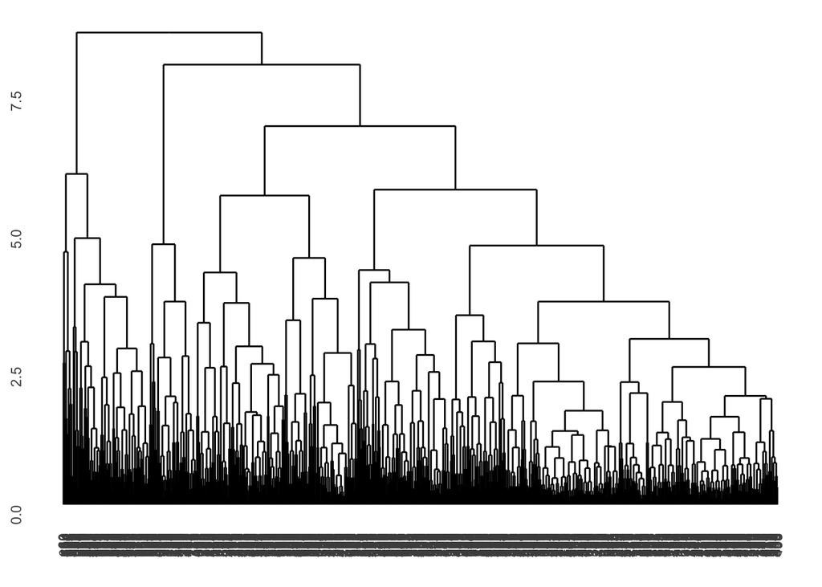

```r
# obtain dendograph for data
college_hclust <- onedata %>%
  mutate(hcl = map2(xmat, "complete", run_hclust),
         dendo = map(hcl, ggdendrogram))
# show the dendo
college_hclust %>% pluck("dendo", 1)
```

```r
# get the cluster data
college_hclust <- college_hclust %>%
  mutate(clusters = map2(hcl, 3, cut_hclust), # Cut dendo
         clust_dat = map2(college, clusters, get_cluster)) # Get cluster info
# show the result
oneclust_result = college_hclust$clust_dat[[1]] %>%
  select("name", "cluster")
oneclust_result
```

```
## # A tibble: 777 x 2
##    name                         cluster
##    <fct>                          <int>
##  1 Abilene Christian University       1
##  2 Adelphi University                 1
##  3 Adrian College                     1
##  4 Agnes Scott College                1
##  5 Alaska Pacific University          1
##  6 Albertson College                  1
##  7 Albertus Magnus College            1
##  8 Albion College                     1
##  9 Albright College                   1
## 10 Alderson-Broaddus College          1
## # … with 767 more rows
```

3. Run spectral clustering using the radial kernel. Set the number of clusters for the algorithm equal to the number of clusters you found useful in parts (a-b). Do you obtain different clusters than those algorithms?

```r
# Fit a spectral cluster w/ 3 clusters
college_spclus <- onedata %>%
  mutate(spec = map2(xmat, 3, specc, kernal = "radial"))
# get cluster info
college_spclus <- college_spclus %>%
  mutate(spec_clus_data = map2(college, spec, get_cluster))
# show the result
spec_result = college_spclus$spec_clus_data[[1]] %>%
  select("name", "cluster")
spec_result
```

```
## # A tibble: 777 x 2
##    name                         cluster
##    <fct>                          <int>
##  1 Abilene Christian University       3
##  2 Adelphi University                 3
##  3 Adrian College                     3
##  4 Agnes Scott College                3
##  5 Alaska Pacific University          3
##  6 Albertson College                  3
##  7 Albertus Magnus College            3
##  8 Albion College                     3
##  9 Albright College                   3
## 10 Alderson-Broaddus College          3
## # … with 767 more rows
```

4. Use the `cluster` package (specifically the `daisy()` & `pam()`) to perform clustering. Again, use the same number of clusters you used on part (a). Do you obtain different clusters?

```r
# cluster observations based on their dissimilarities
college_clusters <- tibble(dat =  scaledcollege %>% list())
college_clusters <- college_clusters %>%
  mutate(dissim = map(dat, daisy),
         clust = map2(dissim, 3, pam))
# function to get cluster info
get_cluster_info = function(x, clust_obj){
    clust = clust_obj$clustering
  out = x %>%
    mutate(cluster = clust)
  return(out)
}

college_clusters <- college_clusters %>%
  mutate(clusters = map2(dat, clust, get_cluster_info)) # Get DFs with cluster affiliation
# show cluster result
cluster_result <- college_clusters$clusters[[1]] %>%
  select("name", "cluster")
```